# Linear Regression

Ziyuan Huang

Last Updated: 2026-01-29

# What is Regression?

- A way of predicting the value of one variable from other variables.
  - It is a hypothetical model of the relationship between two or more variables.
  - The model used is a linear one in these notes, doesn’t always have to be!
  - Therefore, we describe the relationship using the equation of a straight line.
- **Field et al. (2012)** defines regression as: *fitting a model to data and using it to predict values of the dependent variable (DV) from one or more independent variables (IVs)*
- We extend beyond the data we collected to answer predictive questions

# Describing a Straight Line

$$Y_i = b_0 + b_1X_i +
\varepsilon_i$$

**Key Components:**

- $Y_i$ = outcome value for person i
- $b_0$ = intercept (value of Y when X = 0); the point at which the regression line crosses the Y-axis
- $b_1$ = regression coefficient (gradient/slope) of the regression line; the change in Y for each unit change in X
- $X_i$ = predictor value for person i
- $\varepsilon_i$ = residual (error term); the difference between predicted $\hat{Y_i}$ and observed $Y_i$

**All regression coefficients ($b$) are sometimes called:** - Gradient (slope) of the regression line - Direction/Strength of Relationship - Unstandardized coefficients (original scale)

# Intercepts and Gradients

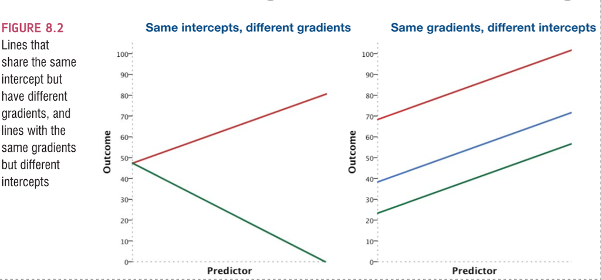

# Types of Regression

- **Simple Linear Regression = SLR**
  - One X variable (IV)
- **Multiple Linear Regression = MLR**
  - 2 or more X variables (IVs)
  - MLR types include:
    - Simultaneous: Everything at once
    - Hierarchical: IVs in steps
    - Stepwise: Statistical regression

# Analyzing a Regression

- Is my overall model *(i.e., the regression equation)* useful at predicting the outcome variable?
  - Use the model summary, F-test, and $R^2$
- How useful are each of the individual predictors for my model?
  - Use the coefficients, t-test, and $pr^2$

# Overall Model: Understand the NHST

# Overall Model: What Do We Mean by “Predict”?

- The General Linear Model:
  $$\text{Outcome} = \text{(Model)} +
  \text{Error}$$
- In regression, we predict each person’s score $Y_i$ by:
  1. **Base prediction** ($b_0$): Starting with the intercept (intercept = predicted Y when X = 0)
  2. **Add predictor influence** ($b_1X_i$): Adding the contribution of each predictor variable
  3. **Account for residual** ($\varepsilon_i$): Acknowledging the difference between predicted $\hat{Y_i}$ and observed $Y_i$ (irreducible error)
- **H0 Model** (No Relationship): Prediction using only the mean, resulting in a flat line ($b_1 = 0$)
- **H1 Model** (Relationship Exists): Prediction using the regression line, incorporating predictor slopes

# Comparing H0 vs H1 Models

- **H0 Model** (top left): You cannot predict $Y_i$ better than using the mean for each person
  - Regression line is flat: $\hat{Y} = b_0$ (intercept only)
  - Large residuals, poor fit
- **H1 Model** (top right): You can predict $Y_i$ by including predictor variables
  - Regression line has slope: $\hat{Y} = b_0 + b_1X_i$
  - Smaller residuals, better fit
  - By including predictors, you decrease the error between observed $Y_i$ and predicted $\hat{Y_i}$

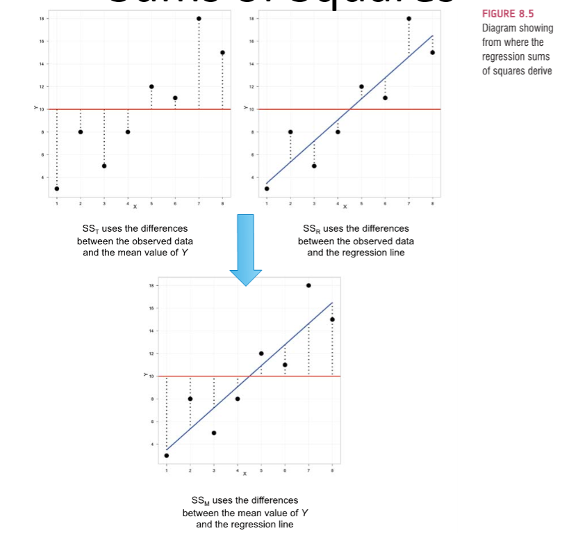

# Method of Least Squares

- **Least Squares**: A mathematical technique that finds the regression line by minimizing the sum of squared differences between observed and predicted values
  - Among all possible lines, we choose the one with **least squared error** (smallest SSR)
  - This ensures the most accurate fit to the data
- **Comparing Models**:
  - We use error size (SSR) to determine if our H1 model (with predictors) is better than our H0 model (without)
  - Equivalently, we can ask if our $R^2$ value (variance explained) is greater than zero
  - **Less error = Higher fit = Higher $R^2$**

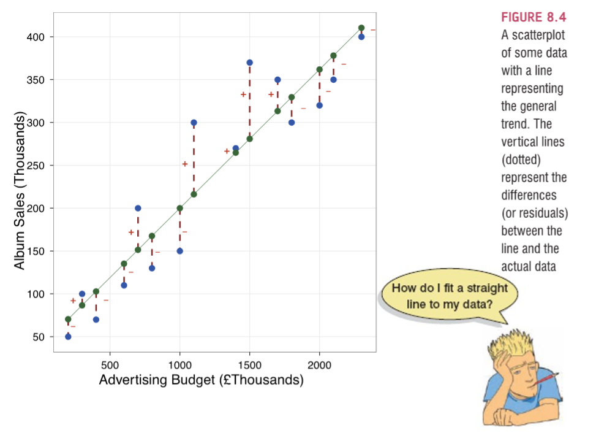

# Sums of Squares in Regression

**Total Sum of Squares (SST):** - Sum of squared differences between observed values and the **mean** of Y - Represents total variability in the outcome with **no predictors** (H0 model) - Formula: $SST = \sum(Y_i - \bar{Y})^2$

**Residual Sum of Squares (SSR):** - Sum of squared differences between observed values and **predicted values** from regression line - Represents variability **unexplained** by the model (error remaining) - Formula: $SSR = \sum(Y_i - \hat{Y_i})^2$

**Model Sum of Squares (SSM):** - Sum of squared differences between predicted values and the **mean** of Y - Represents variability **explained** by the model (improvement from adding predictors) - Formula: $SSM = SST - SSR$ or $SSM = \sum(\hat{Y_i} - \bar{Y})^2$

**Relationship**: $SST = SSM + SSR$ (total variation = explained + unexplained)

# Individual Predictors: Understand the NHST

- We test the individual predictors with a t-test:
  - $t = \frac{b}{SE}$
  - Therefore, the model for each individual predictor is our coefficient b.
  - Single sample t-test to determine if the b value is different from zero

# Individual Predictors: Understand the NHST

- Therefore, we might use the following hypotheses:
  - H0: X variable does not predict Y.
  - H1: X variable does predict Y.
- Or, we could use a directional test, since the test statistic *t* can be negative:
  - H0: X variable negatively or does not predict Y (b <= 0).
  - H1: X variable positively predicts Y (b > 0).

# Individual Predictors: Understand the NHST

- Unlike correlation, these statistics are often reported with *t*(df).
- $df = N - k - 1$
  - N = total sample size
  - k = number of predictors
  - Correlation is technically N - 1 - 1 = N - 2
  - We can also find this value in our output by looking at the *F*-statistic.

# Individual Predictors: Standardization

**Unstandardized Regression Coefficient ($b$):** - Regression coefficient in the **original scale** of the variables - **Interpretation**: For every one unit increase in X, Y increases by $b$ units - **Advantage**: More interpretable for your specific problem context - **Disadvantage**: Hard to compare across predictors with different scales - Formula: Predicted $Y = b_0 + b_1X$

**Standardized Regression Coefficient ($\beta$ or “beta”):** - Regression coefficient after converting variables to standard deviation units - **Interpretation**: For every one **SD** increase in X, Y increases by $\beta$ **SDs** - **Advantage**: Comparable across predictors with different scales; indicates relative importance - **Disadvantage**: Less interpretable for real-world problem context

**When to Use Each:** - Use $b$ for answering applied questions (“How many more sales per $1000 advertising?”) - Use $\beta$ for comparing predictor importance across variables with different scales

# Data Screening

- Now we want to look specifically at the residuals for Y, while screening the X variables.
- We used a random variable before to check the continuous variable (the DV) to make sure they were randomly distributed.
- Now we don’t need the random variable because the residuals for Y should be randomly distributed (and evenly) with the X variable.

# Data Screening

- Accuracy
- Missing
- Outliers - (somewhat) new and exciting!
- Additivity if you have more than one predictor
- Linearity
- Normality
- Homogeneity
- Homoscedasticity

# Example: Mental Health

- Mental Health and Drug Use:
  - CESD = depression measure
  - PIL total = measure of meaning in life
  - AUDIT total = measure of alcohol use
  - DAST total = measure of drug usage

```r
library(rio)
master <- import("data/regression_data.sav")
master <- master[ , c(8:11)]
str(master)
```

```
## 'data.frame':    267 obs. of  4 variables:
##  $ PIL_total      : num  121 76 98 122 99 134 102 124 126 112 ...
##   ..- attr(*, "format.spss")= chr "F8.2"
##   ..- attr(*, "display_width")= int 11
##  $ CESD_total     : num  28 37 20 15 7 7 27 10 9 8 ...
##   ..- attr(*, "format.spss")= chr "F8.2"
##   ..- attr(*, "display_width")= int 12
##  $ AUDIT_TOTAL_NEW: num  1 5 3 3 2 3 2 1 1 7 ...
##   ..- attr(*, "format.spss")= chr "F8.2"
##   ..- attr(*, "display_width")= int 17
##  $ DAST_TOTAL_NEW : num  0 0 0 1 0 0 1 0 0 1 ...
##   ..- attr(*, "format.spss")= chr "F8.2"
##   ..- attr(*, "display_width")= int 16
```

# Example: Accuracy, Missing Data

- All data is accurate with min and max values.
- We only have one missing data point, which we can exclude because with only four columns, we cannot estimate missing data.

```r
summary(master)
```

```
##    PIL_total       CESD_total   AUDIT_TOTAL_NEW  DAST_TOTAL_NEW
##  Min.   : 60.0   Min.   : 0.0   Min.   : 0.000   Min.   :0.000
##  1st Qu.:103.0   1st Qu.: 7.0   1st Qu.: 2.000   1st Qu.:0.000
##  Median :111.0   Median :11.0   Median : 5.000   Median :0.000
##  Mean   :110.7   Mean   :13.2   Mean   : 6.807   Mean   :0.906
##  3rd Qu.:121.0   3rd Qu.:17.0   3rd Qu.:11.000   3rd Qu.:1.000
##  Max.   :138.0   Max.   :47.0   Max.   :31.000   Max.   :9.000
##                                                  NA's   :1
```

```r
nomiss <- na.omit(master)
nrow(master)
```

```
## [1] 267
```

```r
nrow(nomiss)
```

```
## [1] 266
```

# Example: Outliers

- In this section, we will add a few new outlier checks:
  - Mahalanobis
  - Leverage scores
  - Cook’s distance
- Because we are using regression as our model, we may consider using multiple checks before excluding outliers.

# Example: Mahalanobis

- The `mahalanobis()` function we have used previously.
- Since we are going to use multiple criteria, we are going to save if they are an outlier or not.
- The table tells us: 0 (not outliers) and 1 (considered an outlier) for just Mahalanobis values.

```r
mahal <- mahalanobis(nomiss,
                    colMeans(nomiss),
                    cov(nomiss))
cutmahal <- qchisq(1-.001, ncol(nomiss))
badmahal <- as.numeric(mahal > cutmahal) ##note the direction of the >
table(badmahal)
```

```
## badmahal
##   0   1
## 261   5
```

# Example: Other Outliers

- To get the other outlier statistics, we have to use the regression model we wish to test. - We will use the `lm()` function with our regression formula.
- `Y ~ X + X`: Y is approximated by X plus X.
- So we will predict depression scores (CESD) with meaning, drugs, and alcohol.

```r
model1 <- lm(CESD_total ~ PIL_total + AUDIT_TOTAL_NEW + DAST_TOTAL_NEW,
             data = nomiss)
```

# Example: Leverage

- **Definition** - influence of that data point on the slope
- Each score is the change in slope if you exclude that data point
- How do we calculate how much change is bad?
  - $\frac{2K+2}{N}$
  - K is the number of predictors
  - N is the sample size

# Example: Leverage

```r
k <- 3 ##number of IVs
leverage <- hatvalues(model1)
cutleverage <- (2*k+2) / nrow(nomiss)
badleverage <- as.numeric(leverage > cutleverage)
table(badleverage)
```

```
## badleverage
##   0   1
## 247  19
```

# Example: Cook’s Distance

- Influence **(Cook’s Distance)** - a measure of how much of an effect that single case has on the whole model
- Often described as leverage + discrepancy
- How do we calculate how much change is bad?
  - $\frac{4}{N-K-1}$

```r
cooks <- cooks.distance(model1)
cutcooks <- 4 / (nrow(nomiss) - k - 1)
badcooks <- as.numeric(cooks > cutcooks)
table(badcooks)
```

```
## badcooks
##   0   1
## 251  15
```

# Example: Outliers Combined

- What do I do with all these numbers?
- Create a total score for the number of indicators a data point has.
- You can decide what rule to use, but a suggestion is 2 or more indicators is an outlier.

```r
##add them up!
totalout <- badmahal + badleverage + badcooks
table(totalout)
```

```
## totalout
##   0   1   2   3
## 239  17   8   2
```

```r
noout <- subset(nomiss, totalout < 2)
```

# Example: Assumptions

- Now that we got rid of outliers, we need to run that model again, without the outliers.

```r
model2 <- lm(CESD_total ~ PIL_total + AUDIT_TOTAL_NEW + DAST_TOTAL_NEW,
             data = noout)
```

# Example: Additivity

- You want X and Y to be correlated
- You do not want the Xs to be highly correlated, as it causes you to lose power

```r
summary(model2, correlation = TRUE)
```

```
##
## Call:
## lm(formula = CESD_total ~ PIL_total + AUDIT_TOTAL_NEW + DAST_TOTAL_NEW,
##     data = noout)
##
## Residuals:
##     Min      1Q  Median      3Q     Max
## -13.904  -5.086  -1.161   3.405  29.342
##
## Coefficients:
##                 Estimate Std. Error t value Pr(>|t|)
## (Intercept)     54.19317    4.20489  12.888   <2e-16 ***
## PIL_total       -0.37272    0.03629 -10.271   <2e-16 ***
## AUDIT_TOTAL_NEW -0.07774    0.09548  -0.814    0.416
## DAST_TOTAL_NEW   0.72741    0.50953   1.428    0.155
## ---
## Signif. codes:  0 '***' 0.001 '**' 0.01 '*' 0.05 '.' 0.1 ' ' 1
##
## Residual standard error: 7.357 on 252 degrees of freedom
## Multiple R-squared:  0.3157, Adjusted R-squared:  0.3076
## F-statistic: 38.76 on 3 and 252 DF,  p-value: < 2.2e-16
##
## Correlation of Coefficients:
##                 (Intercept) PIL_total AUDIT_TOTAL_NEW
## PIL_total       -0.99
## AUDIT_TOTAL_NEW -0.16        0.06
## DAST_TOTAL_NEW  -0.17        0.15     -0.47
```

# Example: Assumption Set Up

- We use the same code as before, but without the fake regression.

```r
standardized <- rstudent(model2)
fitted <- scale(model2$fitted.values)
```

# Example: Linearity

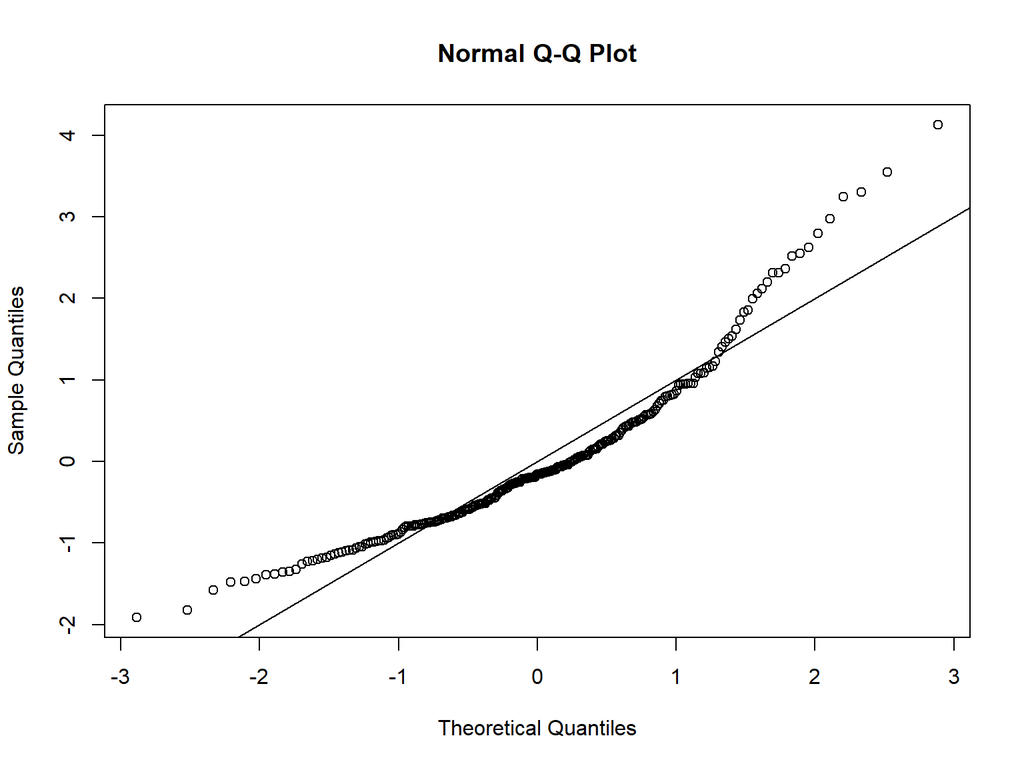

```r
{qqnorm(standardized)
abline(0,1)}
```

# Example: Normality

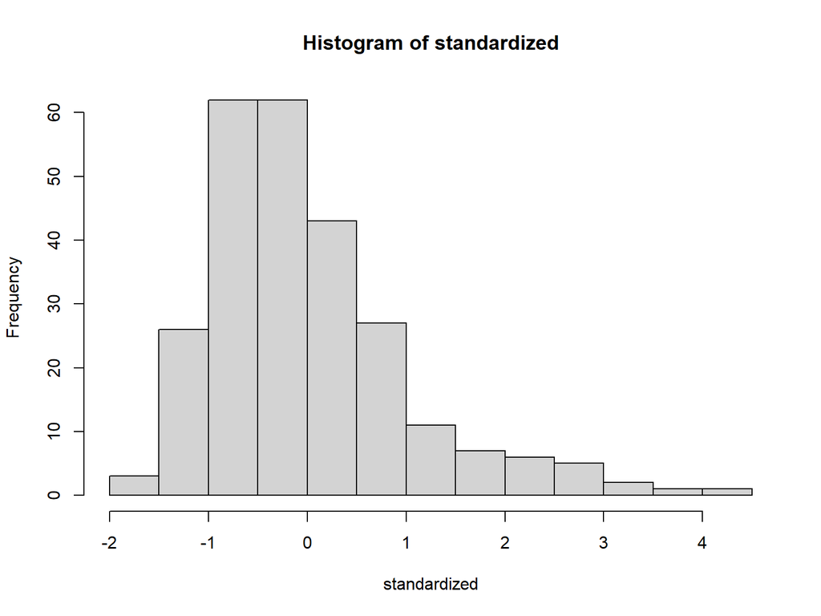

```r
hist(standardized)
```

# Example: Homogeneity & Homoscedasticity

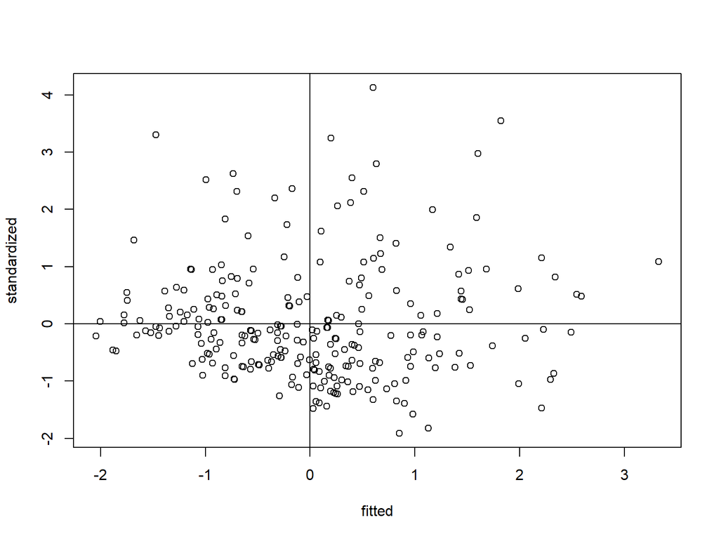

```r
{plot(fitted, standardized)
abline(0,0)
abline(v = 0)}
```

# Example: Assumption Alternatives

- If your assumptions go wrong:
  - Linearity - try nonlinear regression or nonparametric regression
  - Normality - more subjects, still fairly robust
  - Homogeneity/Homoscedasticity - bootstrapping

# Example: Overall Model

- Is the overall model significant? Yes!

```r
summary(model2)
```

```
##
## Call:
## lm(formula = CESD_total ~ PIL_total + AUDIT_TOTAL_NEW + DAST_TOTAL_NEW,
##     data = noout)
##
## Residuals:
##     Min      1Q  Median      3Q     Max
## -13.904  -5.086  -1.161   3.405  29.342
##
## Coefficients:
##                 Estimate Std. Error t value Pr(>|t|)
## (Intercept)     54.19317    4.20489  12.888   <2e-16 ***
## PIL_total       -0.37272    0.03629 -10.271   <2e-16 ***
## AUDIT_TOTAL_NEW -0.07774    0.09548  -0.814    0.416
## DAST_TOTAL_NEW   0.72741    0.50953   1.428    0.155
## ---
## Signif. codes:  0 '***' 0.001 '**' 0.01 '*' 0.05 '.' 0.1 ' ' 1
##
## Residual standard error: 7.357 on 252 degrees of freedom
## Multiple R-squared:  0.3157, Adjusted R-squared:  0.3076
## F-statistic: 38.76 on 3 and 252 DF,  p-value: < 2.2e-16
```

```r
library(papaja)
apa_style <- apa_print(model2)
apa_style$full_result$modelfit
```

```
## $r2
## [1] "$R^2 = .32$, 90\\% CI $[0.23, 0.39]$, $F(3, 252) = 38.76$, $p < .001$"
```

- $R^2 = .32$, 90% CI $[0.23, 0.39]$, $F(3, 252) = 38.76$, $p < .001$

# Example: Predictors

```r
summary(model2)
```

```
##
## Call:
## lm(formula = CESD_total ~ PIL_total + AUDIT_TOTAL_NEW + DAST_TOTAL_NEW,
##     data = noout)
##
## Residuals:
##     Min      1Q  Median      3Q     Max
## -13.904  -5.086  -1.161   3.405  29.342
##
## Coefficients:
##                 Estimate Std. Error t value Pr(>|t|)
## (Intercept)     54.19317    4.20489  12.888   <2e-16 ***
## PIL_total       -0.37272    0.03629 -10.271   <2e-16 ***
## AUDIT_TOTAL_NEW -0.07774    0.09548  -0.814    0.416
## DAST_TOTAL_NEW   0.72741    0.50953   1.428    0.155
## ---
## Signif. codes:  0 '***' 0.001 '**' 0.01 '*' 0.05 '.' 0.1 ' ' 1
##
## Residual standard error: 7.357 on 252 degrees of freedom
## Multiple R-squared:  0.3157, Adjusted R-squared:  0.3076
## F-statistic: 38.76 on 3 and 252 DF,  p-value: < 2.2e-16
```

# Example: Predictors

```r
apa_style$full_result$PIL_total
```

```
## [1] "$b = -0.37$, 95\\% CI $[-0.44, -0.30]$, $t(252) = -10.27$, $p < .001$"
```

```r
apa_style$full_result$AUDIT_TOTAL_NEW
```

```
## [1] "$b = -0.08$, 95\\% CI $[-0.27, 0.11]$, $t(252) = -0.81$, $p = .416$"
```

```r
apa_style$full_result$DAST_TOTAL_NEW
```

```
## [1] "$b = 0.73$, 95\\% CI $[-0.28, 1.73]$, $t(252) = 1.43$, $p = .155$"
```

- Meaning: $b = -0.37$, 95% CI $[-0.44, -0.30]$, $t(252) = -10.27$, $p < .001$
- Alcohol: $b = -0.08$, 95% CI $[-0.27, 0.11]$, $t(252) = -0.81$, $p = .416$
- Drugs: $b = 0.73$, 95% CI $[-0.28, 1.73]$, $t(252) = 1.43$, $p = .155$

# Example: Predictors

- Two concerns:
  - What if I wanted to use beta because these are very different scales?
  - What about an effect size for each individual predictor?

# Example: Beta

- You can use the `QuantPsyc` package for $\beta$ values.

```r
library(QuantPsyc)
lm.beta(model2)
```

```
##       PIL_total AUDIT_TOTAL_NEW  DAST_TOTAL_NEW
##     -0.54695645     -0.04844095      0.08573100
```

# Example: Effect Size

**Multiple Correlation (R):** - The correlation between observed Y and predicted Y values - Ranges from 0 to 1; indicates overall model strength - In simple regression: $R = |r_{XY}|$ (absolute correlation)

**$R^2$ (Coefficient of Determination):** - Proportion of variance in Y **explained** by the model - Formula: $R^2 = \frac{SSM}{SST} = 1 - \frac{SSR}{SST}$ - Interpretation: “The model explains $R^2 \times 100$ percent of the variance in Y” - All overlap in Y, used for overall model - $R^2 = \frac{A+B+C}{A+B+C+D}$ (explained / total)

# Example: Effect Size - Semipartial Correlation

**Semipartial Correlation Squared ($sr^2$):** - **Unique contribution** of this IV to $R^2$ (variance in Y explained only by this predictor, after accounting for other predictors) - The **increase** in $R^2$ when this X is added to the model - Formula: $sr^2 = \frac{A}{A+B+C+D}$ (unique variance / total variance) - **Interpretation**: “Adding this predictor increases $R^2$ by $sr^2 \times 100$ percentage points” - Used in hierarchical regression to show incremental value of each predictor

# Example: Effect Size - Partial Correlation

**Partial Correlation Squared ($pr^2$):** - Proportion of **remaining** variance in Y (after removing other predictors’ influence) that is explained by this X - Formula: $pr^2 = \frac{A}{A+D}$ (unique variance / variance not explained by others) - **Interpretation**: “Among the variance in Y not explained by other predictors, this predictor explains $pr^2 \times 100$ percent” - **Always larger than $sr^2$** because denominator excludes shared variance: $pr^2 > sr^2$ - Often reported alongside $sr^2$ for complete picture of predictor importance

# Example: Partials

- We would add these to our other reports:
  - Meaning: $b = -0.37$, 95% CI $[-0.44, -0.30]$, $t(252) = -10.27$, $p < .001$, $pr^2 = .30$
  - Alcohol: $b = -0.08$, 95% CI $[-0.27, 0.11]$, $t(252) = -0.81$, $p = .416$, $pr^2 < .01$
  - Drugs: $b = 0.73$, 95% CI $[-0.28, 1.73]$, $t(252) = 1.43$, $p = .155$, $pr^2 < .01$

```r
library(ppcor)
partials <- pcor(noout)
partials$estimate^2
```

```
##                   PIL_total  CESD_total AUDIT_TOTAL_NEW DAST_TOTAL_NEW
## PIL_total       1.000000000 0.295101597     0.005899378    0.005606820
## CESD_total      0.295101597 1.000000000     0.002623799    0.008022779
## AUDIT_TOTAL_NEW 0.005899378 0.002623799     1.000000000    0.218315640
## DAST_TOTAL_NEW  0.005606820 0.008022779     0.218315640    1.000000000
```

# Example: Hierarchical Regression

- Known predictors (based on past research) are entered into the regression model first.
- New predictors are then entered in a separate step of the model.
- You can see the unique predictive influence of a new variable on the outcome because known predictors are held constant in the model.
- Should be based on previous research, ideas, or other *a priori* decisions.
- Statistical or stepwise regression also runs models as steps, but variables are included in the equation based on their mathematical properties.

# Hierarchical Regression: Understand the NHST

**Method:** - Known predictors (based on past research) entered first - New predictors entered in separate steps - Tests significance of **each step addition** and individual predictors

**Answers the Following Questions:** - Is my overall model significant? (F-test for final model) - Is the addition of each step significant? (Comparison of $R^2$ between models via $\Delta F$) - Are the individual predictors significant? (t-tests for each coefficient)

**When to Use:** - Control for known/nuisance variables first before testing new predictors - See the **incremental value** of adding new variables to existing model - Discuss groups of variables together as a conceptual set - **Based on a priori theory** (NOT exploratory/stepwise selection)

# Categorical Predictors

- Dealing with categorical (nominal) predictors with more than two categories
- **Note**: All types of regression can include categorical predictors, not only hierarchical regression

**Dummy Coding (Contrast Coding):** - Converts categorical variable into multiple **binary indicators** - Each dummy variable compares one category against a reference category - **Advantage**: Allows interpretation as comparisons (e.g., “Treatment vs. Control”) - Reference category gets value 0 on all dummies - Each non-reference category gets value 1 on its corresponding dummy - If k categories, create k-1 dummy variables - **Interpretation of $b$**: Difference in Y between this category and reference category

**Other Coding Systems:** - Deviation (effect) coding, orthogonal coding, helmert coding: https://stats.idre.ucla.edu/spss/faq/coding-systems-for-categorical-variables-in-regression-analysis/

# Dummy Coding in R

**R handles dummy coding automatically:** - When you use `factor()` to convert a variable to a categorical type - R creates k-1 dummy variables and uses first level as reference category - Each dummy variable shows 1 if observation is in that category, 0 otherwise - Example coding table:

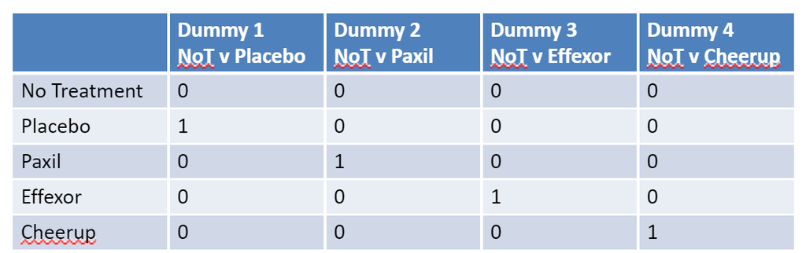

**Change Reference Category in R:**

```r
data$variable <- factor(data$variable,
                       levels = c("ref_category", "cat2", "cat3"))
```

# Example: Hierarchical Regression + Dummy Coding

**Research Question**: Do different depression treatments reduce depression ratings after controlling for family history?

**Variables:** - **IVs**: - Family history of depression (continuous predictor) - Treatment for depression (categorical: No Treatment, Placebo, Paxil, Effexor, Cheerup) - **DV**: Depression rating after treatment (continuous outcome)

```r
hdata <- import("data/dummy_code.sav")
str(hdata)
```

```
## 'data.frame':    50 obs. of  3 variables:
##  $ treat        : num  0 0 0 0 0 0 0 0 0 0 ...
##   ..- attr(*, "label")= chr "Treatment"
##   ..- attr(*, "format.spss")= chr "F8.0"
##   ..- attr(*, "display_width")= int 18
##   ..- attr(*, "labels")= Named num [1:5] 0 1 2 3 4
##   .. ..- attr(*, "names")= chr [1:5] "No Treatment" "Placebo" "Seroxat (Paxil)" "Effexor" ...
##  $ familyhistory: num  6.79 6.88 19.65 10.8 32.27 ...
##   ..- attr(*, "label")= chr "Family History"
##   ..- attr(*, "format.spss")= chr "F8.0"
##  $ after        : num  16 18 13 15 18 16 18 19 9 16 ...
##   ..- attr(*, "label")= chr "After Treatment"
##   ..- attr(*, "format.spss")= chr "F8.0"
```

# Example: Hierarchical Regression + Dummy Coding

- Be sure to factor our categorical variable, or we will be treating categories as a continuous 1, 2, 3!

```r
attributes(hdata$treat)
```

```
## $label
## [1] "Treatment"
##
## $format.spss
## [1] "F8.0"
##
## $display_width
## [1] 18
##
## $labels
##    No Treatment         Placebo Seroxat (Paxil)         Effexor         Cheerup
##               0               1               2               3               4
```

```r
hdata$treat <- factor(hdata$treat,
                     levels = 0:4,
                     labels = c("No Treatment", "Placebo", "Paxil",
                                "Effexor", "Cheerup"))
```

# Example: Hierarchical Regression + Dummy Coding

# Example: Hierarchical Regression + Dummy Coding

**Data Screening**: Should be done on the **LAST** model (skipped here for brevity)

**Model 1: Base Model with Control Variable** - Enter family history alone to establish baseline - Tests if family history alone predicts depression rating

```
- **Overall fit**: $F(1,48) = 8.50, p = .005, R^2 = .15$
- **Interpretation**: Family history accounts for 15% of variance in post-treatment depression
- **Family history predictor**: $b = 0.15, t(48) = 2.92, p = .005, pr^2 = .15$
- **Interpretation**: For each unit increase in family history, depression rating increases 0.15 units
```

```r
model1 <- lm(after ~ familyhistory, data = hdata)
summary(model1)
```

```
##
## Call:
## lm(formula = after ~ familyhistory, data = hdata)
##
## Residuals:
##     Min      1Q  Median      3Q     Max
## -6.5120 -1.9028 -0.2193  2.0544  6.7958
##
## Coefficients:
##               Estimate Std. Error t value Pr(>|t|)
## (Intercept)   11.00363    0.84477  13.026   <2e-16 ***
## familyhistory  0.15313    0.05254   2.915   0.0054 **
## ---
## Signif. codes:  0 '***' 0.001 '**' 0.01 '*' 0.05 '.' 0.1 ' ' 1
##
## Residual standard error: 3.133 on 48 degrees of freedom
## Multiple R-squared:  0.1504, Adjusted R-squared:  0.1327
## F-statistic: 8.495 on 1 and 48 DF,  p-value: 0.005396
```

# Example: Hierarchical Regression + Dummy Coding

# Example: Hierarchical Regression + Dummy Coding

**Model 2: Full Model with Treatment Added** - Add treatment category to Model 1 (keep family history to maintain control) - Tests if treatment **incrementally** predicts depression rating after controlling for family history - The overall model is significant, but **focus on the change between models** (not just overall significance) - Why? If Model 1 was already significant, the overall significance might just reflect Model 1’s contribution - We need $\Delta R^2$ and $\Delta F$ to show treatment adds predictive value beyond family history

```r
model2 <- lm(after ~ familyhistory + treat, data = hdata)
summary(model2)
```

```
##
## Call:
## lm(formula = after ~ familyhistory + treat, data = hdata)
##
## Residuals:
##     Min      1Q  Median      3Q     Max
## -5.7908 -1.6690  0.0508  1.6674  5.4108
##
## Coefficients:
##               Estimate Std. Error t value Pr(>|t|)
## (Intercept)   13.98816    1.09637  12.759  < 2e-16 ***
## familyhistory  0.13513    0.05088   2.656 0.010973 *
## treatPlacebo  -4.09905    1.21381  -3.377 0.001542 **
## treatPaxil    -2.03744    1.22146  -1.668 0.102411
## treatEffexor  -2.59078    1.26984  -2.040 0.047356 *
## treatCheerup  -4.96339    1.22489  -4.052 0.000203 ***
## ---
## Signif. codes:  0 '***' 0.001 '**' 0.01 '*' 0.05 '.' 0.1 ' ' 1
##
## Residual standard error: 2.714 on 44 degrees of freedom
## Multiple R-squared:  0.4154, Adjusted R-squared:  0.349
## F-statistic: 6.254 on 5 and 44 DF,  p-value: 0.0001832
```

# Example: Hierarchical Regression + Dummy Coding

# Example: Hierarchical Regression + Dummy Coding

**Model Comparison via ANOVA:** - Use `anova(model1, model2)` to test: Does treatment add significant predictive value? - **Key statistics**: - $\Delta R^2$: Increase in R² from Model 1 to Model 2 (variance explained by treatment after family history) - $\Delta F$: F-test comparing models’ fit improvements - **Interpretation**: The addition of the treatment set was significant: $\Delta F(4, 44) = 4.99, p = .002, \Delta R^2 = .27$ - Treatment explains an additional 27% of depression rating variance - This improvement is statistically significant (p = .002)

```r
anova(model1, model2)
```

```
## Analysis of Variance Table
##
## Model 1: after ~ familyhistory
## Model 2: after ~ familyhistory + treat
##   Res.Df    RSS Df Sum of Sq      F   Pr(>F)
## 1     48 471.12
## 2     44 324.13  4    146.99 4.9883 0.002102 **
## ---
## Signif. codes:  0 '***' 0.001 '**' 0.01 '*' 0.05 '.' 0.1 ' ' 1
```

# Example: Hierarchical Regression + Dummy Coding

# Example: Hierarchical Regression + Dummy Coding

**Interpreting Dummy-Coded Coefficients:** - Each dummy coefficient ($b$) = **difference between that category and reference category** - **Reference category** (usually first level): automatically set to 0, acts as baseline - **Positive $b$**: That category has higher outcome than reference - **Negative $b$**: That category has lower outcome than reference - $b$ = difference in means, **controlling for (holding constant) other predictors**

**Visualizing Results with `emmeans`:** - Raw $b$ values can be hard to interpret - Estimated Marginal Means (EMMs): Predicted mean Y for each group, given other predictors’ values - **Advantage**: Shows group means on original scale (not as comparisons)

# Example: Hierarchical Regression + Dummy Coding

```r
summary(model2)
```

```
##
## Call:
## lm(formula = after ~ familyhistory + treat, data = hdata)
##
## Residuals:
##     Min      1Q  Median      3Q     Max
## -5.7908 -1.6690  0.0508  1.6674  5.4108
##
## Coefficients:
##               Estimate Std. Error t value Pr(>|t|)
## (Intercept)   13.98816    1.09637  12.759  < 2e-16 ***
## familyhistory  0.13513    0.05088   2.656 0.010973 *
## treatPlacebo  -4.09905    1.21381  -3.377 0.001542 **
## treatPaxil    -2.03744    1.22146  -1.668 0.102411
## treatEffexor  -2.59078    1.26984  -2.040 0.047356 *
## treatCheerup  -4.96339    1.22489  -4.052 0.000203 ***
## ---
## Signif. codes:  0 '***' 0.001 '**' 0.01 '*' 0.05 '.' 0.1 ' ' 1
##
## Residual standard error: 2.714 on 44 degrees of freedom
## Multiple R-squared:  0.4154, Adjusted R-squared:  0.349
## F-statistic: 6.254 on 5 and 44 DF,  p-value: 0.0001832
```

```r
library(emmeans)
emmeans(model2, "treat")
```

```
##  treat        emmean    SE df lower.CL upper.CL
##  No Treatment   15.8 0.858 44    14.11     17.6
##  Placebo        11.7 0.858 44    10.01     13.5
##  Paxil          13.8 0.871 44    12.04     15.6
##  Effexor        13.2 0.930 44    11.37     15.1
##  Cheerup        10.9 0.877 44     9.11     12.6
##
## Confidence level used: 0.95
```

# Example: Hierarchical Regression + Dummy Coding

- We cannot really use the `pcor` code on our categorical variables. What can we do to calculate?
- Formula: $\frac{t^2}{t^2 + df_t}$

```r
model_summary <- summary(model2)
t_values <- model_summary$coefficients[ , 3]
df_t <- model_summary$df[2]

t_values^2 / (t_values^2+df_t)
```

```
##   (Intercept) familyhistory  treatPlacebo    treatPaxil  treatEffexor
##    0.78721534    0.13817150    0.20583673    0.05947423    0.08642805
##  treatCheerup
##    0.27175918
```

# Hierarchical Regression: Power Analysis

- Use the `pwr` library to calculate required **sample size** for desired power and effect size
- **Key concept**: Convert $R^2$ to Cohen’s $f^2$ (effect size for regression, different from ANOVA F)

```r
library(pwr)
R2 <- model_summary$r.squared
f2 <- R2 / (1-R2)

R2
```

```
## [1] 0.4154487
```

```r
f2
```

```
## [1] 0.7107138
```

# Hierarchical Regression: Power

# Hierarchical Regression: Power

**Final Sample Size Calculation:** - Output provides `v` (error df) needed - **Actual N = $v + k + 1$** where k = number of predictors

```r
#f2 is cohen f squared
pwr.f2.test(u = model_summary$df[1],
            v = NULL, f2 = f2,
            sig.level = .05, power = .80)
```

```
##
##      Multiple regression power calculation
##
##               u = 6
##               v = 19.20439
##              f2 = 0.7107138
##       sig.level = 0.05
##           power = 0.8
```

# Summary

In this lecture, we’ve covered:

**Foundations:** - Regression equation and interpretation of coefficients ($b_0$, $b_1$, $\varepsilon$) - Method of least squares for finding best-fit line - Sums of squares (SST, SSR, SSM) and their meaning

**Model Evaluation:** - F-test for overall model significance - $R^2$ and $R$ as effect sizes for model fit - Comparison of H0 (mean-only) vs. H1 (regression) models

**Individual Predictors:** - t-tests and hypothesis testing for coefficients - Unstandardized ($b$) vs. standardized ($\beta$) coefficients - Partial and semipartial correlations for relative importance

**Advanced Topics:** - Regression assumptions and data screening - Outlier detection (Mahalanobis, leverage, Cook’s D) - Hierarchical regression with model comparison - Categorical predictors and dummy coding - Power analysis for sample size planning

**Field et al. (2012) reference:** Chapter 7, *Discovering Statistics Using R*